# Generalized Linear Regression with `brms`

### (d)

Extract the posteriors means and 95% CrIs for the relationships between `straight`, `log_RT_s` and `group` for representative range of `log_RT_s` values. Plot the logistic regression lines for both groups into one graph. Color code the regression lines according to `group`.

```r
model1b_preds <- model1b %>%
  spread_draws(b_Intercept, b_log_RT_s, b_grouptouch, `b_log_RT_s:grouptouch`) %>%
  mutate(log_RT = list(seq(-10, 20, 0.5))) %>%
  unnest(log_RT) %>%
  mutate(click_pred = plogis(b_Intercept + b_log_RT_s*log_RT),
         touch_pred = plogis(b_Intercept + b_grouptouch*log_RT + `b_log_RT_s:grouptouch`*log_RT)) %>%
  group_by(log_RT) %>%
  summarise(lower_CrI_click = quantile(click_pred, prob = 0.025),
            mean_CrI_click = mean(click_pred, na.rm = TRUE),
            upper_CrI_click = quantile(click_pred, prob = 0.975),
            lower_CrI_touch = quantile(touch_pred, prob = 0.025),
            mean_CrI_touch = mean(touch_pred, na.rm = TRUE),
            upper_CrI_touch = quantile(touch_pred, prob = 0.975)
            )

model1b_preds
```

```
## # A tibble: 61 x 7
##    log_RT lower_CrI_click mean_CrI_click upper_CrI_click lower_CrI_touch
##     <dbl>           <dbl>          <dbl>           <dbl>           <dbl>
##  1  -10             0.843          0.950           0.990        0.000126
##  2   -9.5           0.837          0.946           0.989        0.000205
##  3   -9             0.831          0.941           0.986        0.000335
##  4   -8.5           0.825          0.935           0.983        0.000546
##  5   -8             0.818          0.929           0.980        0.000889
##  6   -7.5           0.811          0.922           0.976        0.00145
##  7   -7             0.805          0.915           0.971        0.00235
##  8   -6.5           0.797          0.907           0.965        0.00384
##  9   -6             0.790          0.898           0.959        0.00623
## 10   -5.5           0.782          0.888           0.951        0.0101
## # … with 51 more rows, and 2 more variables: mean_CrI_touch <dbl>,
## #   upper_CrI_touch <dbl>
```

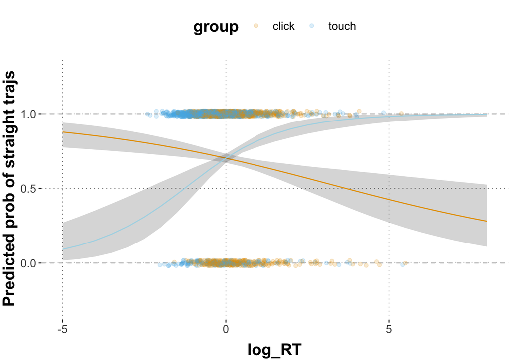

```r
ggplot(data = model1b_preds, aes(x = log_RT, y = mean_CrI_click)) +
  geom_hline(yintercept = c(0,1), lty = "dashed", color = "grey") +
  geom_point(data = dolphin_agg,
             aes(x = log_RT_s, y = as.numeric(as.character(straight)), color = group),
             position = position_jitter(height = 0.02), alpha = 0.2) +
  geom_ribbon(aes(ymin = lower_CrI_click, ymax = upper_CrI_click), alpha = 0.2) +
  geom_line(color = "#E69F00", na.rm = T) +
  geom_ribbon(aes(ymin = lower_CrI_touch, ymax = upper_CrI_touch), alpha = 0.2) +
  geom_line(aes(x = log_RT, y = mean_CrI_touch), color = "lightblue", na.rm = T) +
  ylab("Predicted prob of straight trajs") +
  ylim(-0.3,1.3) +
  xlim(-5, 8)
```

### (e)

Assume we want to predict `correct` responses based on `condition`. We look at the touch group only. Set up a data frame and plot the data as a point plot. (Remember how to jitter the data points)

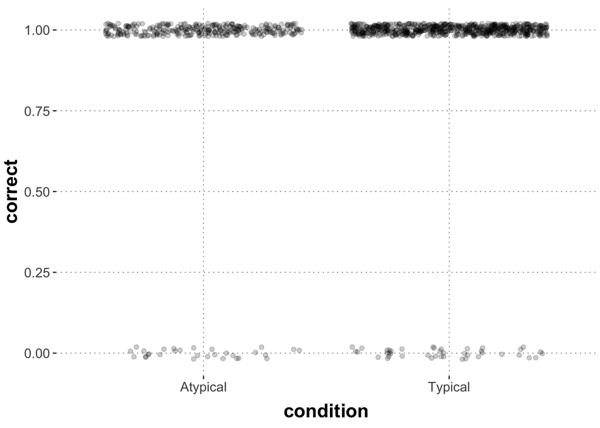

```r
dolphin_agg_ex1e <-
  dolphin %>% filter(group == "touch") %>% select(correct, condition)

dolphin_agg_ex1e %>%
  ggplot(aes(x = condition, y = correct)) +
  geom_point(position = position_jitter(height=0.02), alpha=0.2)
```

### (f)

Run the appropriate generalized linear model in `brms` that predicts `correct` responses based on `condition`. Extract the posterior means and 95% CrIs for the effect of `condition` on `correct` and plot them as points and whiskers into one plot superimposed on the data.

```r
model1f <- brm(
  correct ~ condition,
  dolphin_agg_ex1e,
  family = "bernoulli"
)
```

```
## recompiling to avoid crashing R session
```

```r
model1f
```

```
##  Family: bernoulli
##   Links: mu = logit
## Formula: correct ~ condition
##    Data: dolphin_agg_ex1e (Number of observations: 1045)
## Samples: 4 chains, each with iter = 2000; warmup = 1000; thin = 1;
##          total post-warmup samples = 4000
##
## Population-Level Effects:
##                  Estimate Est.Error l-95% CI u-95% CI Rhat Bulk_ESS Tail_ESS
## Intercept            2.32      0.19     1.95     2.71 1.00     3981     2394
## conditionTypical     0.47      0.25    -0.02     0.96 1.00     3211     2690
##
## Samples were drawn using sampling(NUTS). For each parameter, Bulk_ESS
## and Tail_ESS are effective sample size measures, and Rhat is the potential
## scale reduction factor on split chains (at convergence, Rhat = 1).
```

```r
dolphin_agg_ex1e$condition_numeric <- as.numeric(as.factor(dolphin_agg_ex1e$condition))-1

#model2_preds <- model2 %>%
#  spread_draws(b_Intercept, b_conditionTypical) %>%
#  mutate(correct = list(seq(0,1,1))) %>%
#  unnest(correct) %>%
#  mutate(pred = plogis(b_Intercept + b_conditionTypical * dolphin_agg_ex1e$condition_numeric)) %>%
#  group_by(correct) %>%
#  summarise(pred_m = mean(pred, na.rm = TRUE),
#            pred_low = quantile(pred, prob = 0.025),
#            pred_high = quantile(pred, prob = 0.975))
```

## Exercise 2 *HOMEWORK*

- If you need help, take a look at the suggested readings in the lecture, make use of the Forum, make use of the Forum, and also make use of the Forum.
- Use this exercise Rmd-file, solve the exercises marked as homework (this section here) and save the file with your student number and name in the ‘author’ heading.
- ‘Knit’ the document to produce a HTML file. If knitting fails, make use of the Forum ;)
- **Please do not suppress the code in the HTML-Output!**
- Create a ZIP archive called “MATRIKELNR_Lastname_Firstname_ABDA_Week10.zip” containing:
  - an R Markdown file “MATRIKELNR_Lastname_Firstname_ABDA_Week10.Rmd” and
  - a knitted HTML document “MATRIKELNR_Lastname_Firstname_ABDA_Week10.html”
- Upload the ZIP archive on Stud.IP in the homework folder before the deadline. You may upload as many times as you like before the deadline, only your final submission will count.

### (a) (10 points)

We will continue to use `dolphin_agg` in this exercise. Plot the relationship between `xpos_flips` and `log_RT_s` in a scatterplot and visually differentiate between `condition`s as you see fit.

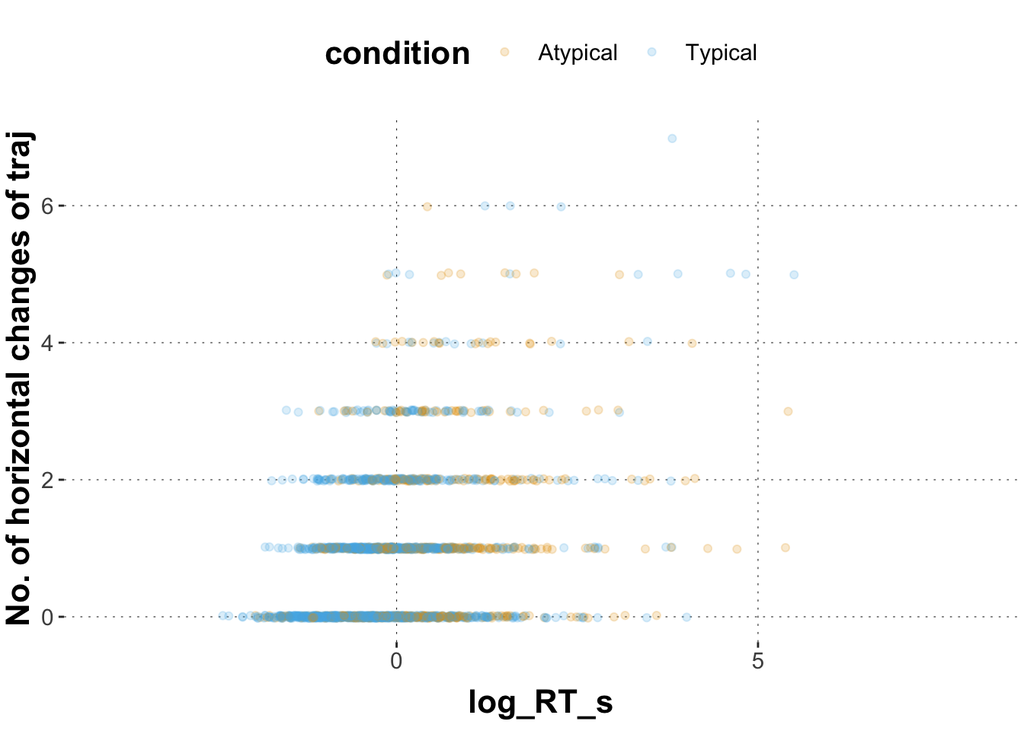

```r
dolphin_agg %>%
  ggplot(aes(x = log_RT_s, y = xpos_flips, color = condition)) +
  geom_point(position = position_jitter(height = 0.02), alpha = 0.2) +
  xlim(-4, 8) +
  ylab("No. of horizontal changes of traj")
```

### (b) (10 points)

Run an appropriate generalized regression model for xflips with `brms` to predict `xpos_flips` based on `log_RT_s`, `condition`, and their two-way interaction.

```r
model2b <- brm(
  xpos_flips ~ log_RT_s * condition,
  dolphin_agg,
  family = "poisson")
```

### (c) (25 points)

Extract the posterior means and 95% CrIs across a range of representative values of log_RT_s (see walkthrough) for both conditions and plot them against the data (as done before in walkthrough and exercise 1).

```r
model2b
```

```
##  Family: poisson
##   Links: mu = log
## Formula: xpos_flips ~ log_RT_s * condition
##    Data: dolphin_agg (Number of observations: 1915)
## Samples: 4 chains, each with iter = 2000; warmup = 1000; thin = 1;
##          total post-warmup samples = 4000
##
## Population-Level Effects:
##                           Estimate Est.Error l-95% CI u-95% CI Rhat Bulk_ESS
## Intercept                    -0.09      0.05    -0.19    -0.00 1.00     2505
## log_RT_s                      0.26      0.03     0.19     0.32 1.00     2040
## conditionTypical             -0.18      0.06    -0.30    -0.07 1.00     2480
## log_RT_s:conditionTypical     0.10      0.04     0.02     0.18 1.00     1919
##                           Tail_ESS
## Intercept                     2499
## log_RT_s                      2357
## conditionTypical              2422
## log_RT_s:conditionTypical     2152
##
## Samples were drawn using sampling(NUTS). For each parameter, Bulk_ESS
## and Tail_ESS are effective sample size measures, and Rhat is the potential
## scale reduction factor on split chains (at convergence, Rhat = 1).
```

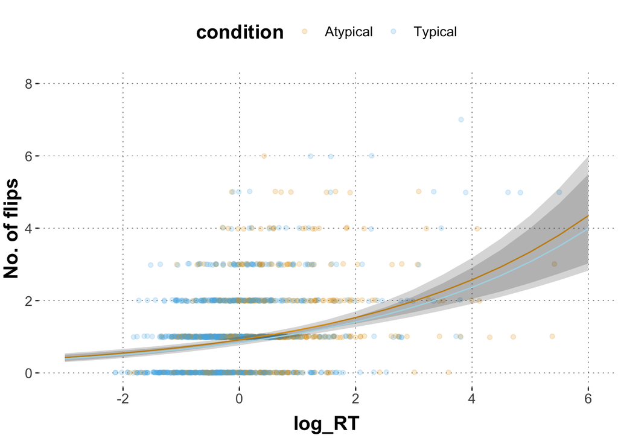

```r
model2b_preds <- model2b %>%
  spread_draws(b_Intercept, b_log_RT_s, b_conditionTypical, `b_log_RT_s:conditionTypical`) %>%
  mutate(log_RT = list(seq(-5, 10, 0.5))) %>%
  unnest(log_RT) %>%
  mutate(predAtypical = exp(b_Intercept + b_log_RT_s * log_RT),
         predTypical = exp(b_Intercept + b_log_RT_s * log_RT + b_conditionTypical + `b_log_RT_s:conditionTypical`)) %>%
  group_by(log_RT) %>%
  summarise(lower_Atypical_pred = quantile(predAtypical, prob = 0.025),
            mean_Atypical_pred = mean(predAtypical, na.rm = TRUE),
            upper_Atypical_pred = quantile(predAtypical, prob = 0.975),
            lower_Typical_pred = quantile(predTypical, prob = 0.025),
            mean_Typical_pred = mean(predTypical, na.rm = TRUE),
            upper_Typical_pred = quantile(predTypical, prob = 0.975))

ggplot(data = model2b_preds, aes(x = log_RT, y = mean_Atypical_pred)) +
  geom_point(data = dolphin_agg, aes(x = log_RT_s, y = xpos_flips, color = condition),
             position = position_jitter(height = 0.02), alpha = 0.2, na.rm = T) +
  geom_ribbon(aes(ymin = lower_Atypical_pred, ymax = upper_Atypical_pred), alpha = 0.2) +
  geom_line(color = "#E69F00", na.rm = T) +
  geom_ribbon(aes(ymin = lower_Typical_pred, ymax = upper_Typical_pred), alpha = 0.2) +
  geom_line(aes(x = log_RT, y = mean_Typical_pred), color = "lightblue", na.rm = T) +
  ylab("No. of flips") +
  ylim(0, 8) +
  xlim(-3, 6)
```

### Bonus

Binary logistic regression assumes that the outcome variable comes from a Bernoulli distribution which is a special case of a binomial distribution where the number of trial $n = 1$ and thus the outcome variable can only be 1 or 0. In contrast, binomial logistic regression assumes that the number of the target events follows a binomial distribution with $n$ trials and probability $q$. Read up on Binomial data with `brms` here: https://www.rensvandeschoot.com/tutorials/generalised-linear-models-with-brms/

Take the following subset of the `dolphin` data frame that only contains `correct` responses (= `1`).

```r
# set up data frame
dolphin_sub <- dolphin %>%
  filter(correct == 1) %>%
  mutate(straight = (ifelse(prototype_label == "straight", 1, 0)),
         log_RT_s = scale(log(RT)))
```

### Bonus (a)

For each `subject_id` in each `group`, aggregate the mean log_RT_s, the number of trials that are classified as `straight` trajectories, and the total number of trials. Plot the proportion of trials that are classified as `straight` (vs. all trials) trajectories for each subject.

### Bonus (b)

Formulate a binomial logistic regression model to predict the proportion of straight trajectories based on `log_RT_s`, `group`, and their two-way interaction. Note that these proportional data are not assumed to be generated by a Bernoulli distribution, but a binomial distribution. Take that into account. Check this tutorial to see how to implement this in `brms`:

https://www.rensvandeschoot.com/tutorials/generalised-linear-models-with-brms/

Extract posterior means and 95% CrIs for the effect of `log_RT_s` for both `group`s and plot them across a representative range of log_RT_s (as done before in this week).

### Bonus (c)

Now compare the results from this analysis to the results from the model 1b above which you plotted in 1d. How do the model results differ and why could that be? (Feel free to explore the data to understand what is going on)

```r
# Answer:
```